# Estrategias de Representación de Texto Dispersas (Sparse)

La representación del texto consiste en transformar secuencias de símbolos en una representación numérica (vectores) que permita el uso de algoritmos de Machine Learning. En este notebook exploraremos:

1. **Bolsa de Palabras (BoW):** Frecuencia de ocurrencia.
2. **Matriz TF-IDF:** Ponderación por relevancia.
3. **Análisis de Dispersión:** Entender por qué los vectores están llenos de ceros.

## 1. Importación de librerías y dataset

Vamos a usar uno de los datasets que ofrece **SciKit-Learn**. Este es un dataset de grupos de noticias (*newsgroups*) que contiene aproximadamente 20,000 publicaciones en foros sobre 20 temas diferentes.

Para efectos prácticos y para que los resultados sean más fáciles de interpretar, vamos a trabajar con un subconjunto de **3 categorías**:

- `sci.space`: Discusiones sobre astronomía y tecnología espacial.
- `rec.autos`: Debates sobre compra, venta y mecánica de automóviles.
- `alt.atheism`: Discusiones filosóficas sobre el ateísmo.

*Nota: Los dataset contienen encabezados, firmas y citas. Por esto al cargar los datos, los eliminaremos para modelar solo el contenido real del mensaje y no de metadatos como correos electrónicos o nombres.*

```python
import pandas as pd
import numpy as np
from sklearn.datasets import fetch_20newsgroups
from sklearn.feature_extraction.text import CountVectorizer, TfidfVectorizer
from sklearn.model_selection import train_test_split
from sklearn.naive_bayes import MultinomialNB
from sklearn.metrics import classification_report, confusion_matrix


# Definimos las categorías
categories = ['sci.space', 'rec.autos', 'alt.atheism']

# Descargamos el dataset
raw_data = fetch_20newsgroups(subset='all', categories=categories,
                             remove=('headers', 'footers', 'quotes'))

# Creamos un DataFrame para que sea más fácil de manipular
df = pd.DataFrame({'texto': raw_data.data, 'clase': raw_data.target})

# Limpiamos filas que hayan quedado vacías tras la remoción de headers/footers
df = df[df['texto'].str.strip() != ""]

print(f"Total de documentos cargados: {len(df)}")
df.head()
```

```
Total de documentos cargados: 2671
```

|  | texto | clase |
| --- | --- | --- |
| 0 | \nTammy, is this all explicitly stated in the ... | 0 |
| 1 | \nSo what do we have now, an integral over pai... | 0 |
| 2 | \nPerhaps because you just made it up? | 0 |
| 3 | Archive-name: space/astronaut\nLast-modified: ... | 2 |
| 4 | I test drove a Mazda 626 LX this past weekend ... | 1 |

## 1. Limpieza: Tokenización y Stemming

Antes de contar palabras, debemos estandarizarlas. No queremos que la máquina piense que "Correr", "Corrió" y "Corriendo" son cosas totalmente distintas. Para esto vamos a usar las siguientes técnicas:

- **Tokenización:** Dividir el texto en palabras individuales.
- **Stemming:** Cortar la palabra de forma cruda para dejar la raíz (ej: "computadoras" -> "comput").

```python
import nltk
from nltk.stem import PorterStemmer, WordNetLemmatizer
from nltk.tokenize import word_tokenize

nltk.download('punkt_tab')
```

```
True
```

```python
stemmer = PorterStemmer()
lemmatizer = WordNetLemmatizer()

ejemplo = "The rockets are launching into space"
tokens = word_tokenize(ejemplo.lower())

print(f"Original: {ejemplo}")
print(f"Tokens: {tokens}")
print(f"Stemming: {[stemmer.stem(t) for t in tokens]}")
```

```
Original: The rockets are launching into space
Tokens: ['the', 'rockets', 'are', 'launching', 'into', 'space']
Stemming: ['the', 'rocket', 'are', 'launch', 'into', 'space']
```

### ¿Para qué nos sirve el Stemming en Machine Learning?

Si dejamos las palabras tal cual, el modelo trataría a "rocket" (singular) y "rockets" (plural) como dos columnas distintas en nuestra matriz.

Al aplicar Stemming, unificamos ambas en la raíz `rocket`. Esto tiene dos beneficios principales:

1. **Reducción de dimensionalidad:** Menos columnas en nuestra matriz dispersa.
2. **Densidad de información:** Agrupamos el significado de palabras similares en una sola característica.

Ahora aplicaremos esto a nuestro dataset...

```python
def limpiar_texto(texto):
    tokens = word_tokenize(texto.lower())
    return " ".join([stemmer.stem(t) for t in tokens if t.isalnum()])

df['texto_limpio'] = df['texto'].apply(limpiar_texto)

print("Texto original:", df['texto'][0][:100])
print("Texto procesado:", df['texto_limpio'][0][:100])
```

```
Texto original:
Tammy, is this all explicitly stated in the bible, or do you assume
that you know that Ezekiel indi
Texto procesado: tammi is thi all explicitli state in the bibl or do you assum that you know that ezekiel indirectli
```

## 1. Representación de Bolsa de Palabras (BOW)

### ¿Cómo funciona CountVectorizer?

`CountVectorizer` es una herramienta de Scikit-Learn que convierte texto en una matriz numérica utilizando el enfoque **Bag of Words (BoW)**.

El proceso que realiza internamente es:

1. **Tokenización**: divide el texto en palabras.
2. **Normalización**: convierte todo a minúsculas.
3. **Construcción del vocabulario**: crea una lista con todas las palabras únicas del corpus.
4. **Vectorización**: cada documento se convierte en un vector donde cada posición corresponde a una palabra del vocabulario y el valor es la cantidad de veces que aparece.

La matriz resultante tiene la forma:

Documentos x Palabras del vocabulario

La clase `CountVectorizer` de scikit-learn realiza la tokenización y el conteo automáticamente. Por defecto:

1. Convierte a minúsculas (`lowercase=True`).
2. Elimina puntuación y tokens de menos de 2 caracteres.
3. Construye un vocabulario global.

### Parámetros a tener en cuenta:

- **`lowercase`**: Por defecto `True`, normaliza todo a minúsculas.
- **`stop_words`**: Lista personalizada de palabras a ignorar (como "the", "a").
- **`max_df` (Frecuencia Máxima)**: Ignora términos que aparecen en más del X% de los documentos. Útil para eliminar palabras con bajo poder discriminativo.
- **`min_df` (Frecuencia Mínima)**: Ignora términos que aparecen en menos de X documentos. Ayuda a eliminar "outliers" o errores de escritura.
- **`token_pattern`**: Permite definir reglas de tokenización mediante expresiones regulares.
- **`max_features`**: Limita el tamaño del vocabulario a las N palabras más frecuentes.

Por ahora veamos un ejemplo pequeño de los vectores que forma `CountVectorizer`

```python
# Ejemplo simple para entender Bag of Words

corpus = [
    "the rocket launched",
    "the rocket exploded",
    "the car is fast"
]

vectorizador_demo = CountVectorizer()

X_demo = vectorizador_demo.fit_transform(corpus)

print("\nPalabras del primer documento:")
print(vectorizador_demo.get_feature_names_out()[X_demo[0].nonzero()[1]])

print("Vocabulario:", vectorizador_demo.get_feature_names_out())

# Palabras presentes en el documento 0
print("\nVector del primer documento:")
print(X_demo[0].toarray())
```

```
Palabras del primer documento:
['the' 'rocket' 'launched']
Vocabulario: ['car' 'exploded' 'fast' 'is' 'launched' 'rocket' 'the']

Vector del primer documento:
[[0 0 0 0 1 1 1]]
```

Cada fila representa un documento. Cada columna representa una palabra del vocabulario El valor indica **cuántas veces aparece esa palabra en el documento**.

Es por esto que para este primer documento, `launched`, `rocket` y `the` tienen el valor de 1.

Ahora veamos la matriz que se genera con todos los documentos

```python
print("\nDimensión de la matriz:", X_demo.shape)

print("\nMatriz BoW:")
print(X_demo.toarray())
```

```
Dimensión de la matriz: (3, 7)

Matriz BoW:
[[0 0 0 0 1 1 1]
 [0 1 0 0 0 1 1]
 [1 0 1 1 0 0 1]]
```

Y a continuación el tipo de dato que generó `CountVectorizer`

```python
print(type(X_demo))
```

```
<class 'scipy.sparse._csr.csr_matrix'>
```

El resultado **NO es una matriz normal**, sino una matriz dispersa (`scipy.sparse`).

### ¿Qué es una Matriz Dispersa (Sparse Matrix)?

En un escenario real con miles de documentos y palabras, la mayoría de los documentos no contienen la mayoría de las palabras.

> **Nota técnica:** `scikit-learn` devuelve un objeto tipo `scipy.sparse`. Esto ahorra memoria guardando solo las posiciones donde el valor NO es cero. Si intentáramos guardar todos los ceros de un vocabulario de 50,000 palabras, agotaríamos la RAM de Colab rápidamente.

### ¿Por qué usamos Matrices Dispersas (Sparse)?

El vocabulario puede tener 50,000 palabras, pero un documento promedio solo usa 50. Guardar un vector lleno de ceros sería un desperdicio de memoria RAM.

- **Sparsity:** La mayoría de las posiciones son cero.
- **Eficiencia:** Scikit-learn usa `scipy.sparse` para almacenar solo los valores diferentes a cero y sus coordenadas.

```python
# Palabras presentes en el documento 0
vectorizador_demo.get_feature_names_out()[X_demo[0].nonzero()[1]]
```

```
array(['the', 'rocket', 'launched'], dtype=object)
```

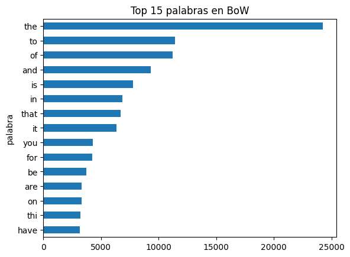

```python
from sklearn.feature_extraction.text import CountVectorizer
import matplotlib.pyplot as plt

vectorizador_bow = CountVectorizer(max_features=15)
X_bow = vectorizador_bow.fit_transform(df['texto_limpio'])

counts = X_bow.toarray().sum(axis=0)
words = vectorizador_bow.get_feature_names_out()

# Ordenar por cantidad para el gráfico
df_bow = pd.DataFrame({'palabra': words, 'conteo': counts}).sort_values('conteo', ascending=True)

df_bow.plot.barh(x='palabra', y='conteo', legend=False)
plt.title("Top 15 palabras en BoW")
plt.show()
```

Al observar el gráfico, notamos algo evidente: las palabras más frecuentes son **"the", "to", "of", "and", "is"**.

Este resultado nos presenta dos grandes problemas para nuestro modelo de Machine Learning:

1. **Falta de Discriminación:** Estas palabras son stop-words y aparecen en prácticamente todos los documentos, sin importar si el tema es el espacio, autos o religión. Si todas las clases tienen las mismas palabras frecuentes, el modelo no tiene de dónde agarrarse para diferenciarlas.
2. **Ruido Matemático:** En un vector de características, los valores más altos deberían representar la esencia del mensaje. Aquí, la palabra "the" tiene un peso de más de 20,000, mientras que palabras clave como "NASA" o "engine" probablemente tienen valores mucho menores.

Para mejorar nuestra representación, necesitamos una técnica que:

- **Ignore** o penalice las palabras que son comunes en todo el dataset.
- **Resalte** las palabras que son frecuentes en un documento específico pero raras en los demás.

## 3. Representación con TF-IDF (Relevancia)

A diferencia de Bag of Words, **TF-IDF** no solo cuenta palabras. Su objetivo es identificar qué palabras son **firmas distintivas** de cada documento.

La fórmula se compone de dos partes:

1. **TF (Term Frequency):** Cuántas veces aparece la palabra en un documento.
2. **IDF (Inverse Document Frequency):** Penaliza las palabras que aparecen en demasiados documentos (como "the", "is", "a").

$$TF-IDF = TF \times \log\left(\frac{N}{df}\right)$$

Donde $N$ es el total de documentos y $df$ es el número de documentos que contienen la palabra. Si una palabra aparece en todos los correos, el logaritmo se vuelve 0 y el peso de la palabra se anula.

### Parámetros específicos de TfidfVectorizer:

- **`stop_words`**: Elimina palabras comunes.
- **`max_features`**: Limita el tamaño del vocabulario.
- **`min_df / max_df`**: Controlan qué palabras se incluyen.
- **`ngram_range`**: Permite usar combinaciones de palabras.
- **`use_idf`**: Por defecto `True`. Si se pone en `False`, se comporta como un CountVectorizer normalizado.
- **`smooth_idf`**: Añade 1 al numerador y denominador de la fórmula para evitar divisiones por cero.
- **`norm`**: Por defecto `l2`. Asegura que cada vector de documento tenga una norma de una unidad.

```python
corpus = [
    "the rocket launched into space",
    "the rocket exploded during launch",
    "the car engine is powerful"
]

tfidf = TfidfVectorizer()

X_tfidf_small = tfidf.fit_transform(corpus)

print("Vocabulario:")
print(tfidf.get_feature_names_out())

print("\nMatriz TF-IDF:")
print(X_tfidf_small.toarray())
```

```
Vocabulario:
['car' 'during' 'engine' 'exploded' 'into' 'is' 'launch' 'launched'
 'powerful' 'rocket' 'space' 'the']

Matriz TF-IDF:
[[0.         0.         0.         0.         0.50461134 0.
  0.         0.50461134 0.         0.38376993 0.50461134 0.29803159]
 [0.         0.50461134 0.         0.50461134 0.         0.
  0.50461134 0.         0.         0.38376993 0.         0.29803159]
 [0.47952794 0.         0.47952794 0.         0.         0.47952794
  0.         0.         0.47952794 0.         0.         0.28321692]]
```

```python
print("Vector TF-IDF del documento 1:")
print(X_tfidf_small[0].toarray())
```

```
Vector TF-IDF del documento 1:
[[0.         0.         0.         0.         0.50461134 0.
  0.         0.50461134 0.         0.38376993 0.50461134 0.29803159]]
```

```python
doc_vector = X_tfidf_small[0].toarray().flatten()

df_importancia = pd.DataFrame({
    "palabra": tfidf.get_feature_names_out(),
    "peso": doc_vector
})

df_importancia = df_importancia.sort_values(by="peso", ascending=False)

df_importancia.head()
```

|  | palabra | peso |
| --- | --- | --- |
| 7 | launched | 0.504611 |
| 10 | space | 0.504611 |
| 4 | into | 0.504611 |
| 9 | rocket | 0.383770 |
| 11 | the | 0.298032 |

Las palabras con mayor peso TF-IDF son las que mejor caracterizan el documento. Por ejemplo,`launched` y `space` tienen un peso alto.

Mientras que palabras comunes como `the` tienen menor peso.

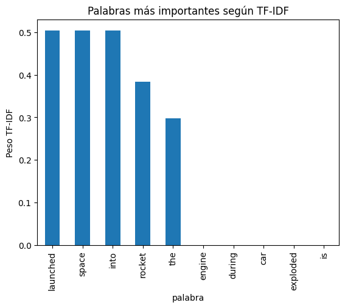

```python
import matplotlib.pyplot as plt

df_importancia.head(10).plot.bar(x="palabra", y="peso", legend=False)

plt.title("Palabras más importantes según TF-IDF")
plt.ylabel("Peso TF-IDF")
plt.show()
```

Ya lo podemos aplicar al dataset completo para ver nuestros resultados

```python
# Aplicamos TF-IDF al dataset
tfidf_vec = TfidfVectorizer(max_features=20, stop_words='english')
X_tfidf = tfidf_vec.fit_transform(df['texto_limpio'])
```

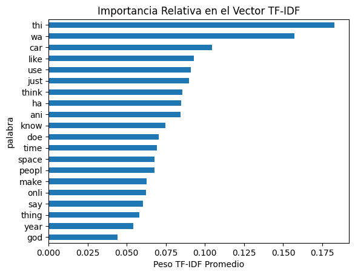

```python
# Gráfica de importancia promedio

vocab = tfidf_vec.get_feature_names_out()
pesos = X_tfidf.mean(axis=0).A1
df_resumen = pd.DataFrame({'palabra': vocab, 'peso': pesos}).sort_values('peso', ascending=True)

df_resumen.plot.barh(x='palabra', y='peso', legend=False)
plt.title("Importancia Relativa en el Vector TF-IDF")
plt.xlabel("Peso TF-IDF Promedio")
plt.show()
```

- **`car`**: Identificador claro de la categoría `rec.autos`.
- **`space`**: Identificador de `sci.space`.
- **`god` / `think`**: Palabras clave de `alt.atheism`.

TF-IDF logró identificar que, aunque "the" es muy frecuente, no es **especial**. En cambio, `car` es frecuente en algunos textos pero raro en los demás, lo que la hace una característica de alto valor.

## 4. Clasificación de textos con Regresión Logística

Ahora que convertimos el texto en vectores numéricos usando TF-IDF, podemos entrenar un modelo de Machine Learning.

Usaremos **Regresión Logística**, un modelo ampliamente usado en clasificación de texto porque, permite **interpretar los coeficientes del modelo**

Los coeficientes indican **qué palabras son más importantes para predecir cada clase**.

```python
from sklearn.model_selection import train_test_split

X_train, X_test, y_train, y_test = train_test_split(
    X_tfidf,
    df['clase'],
    test_size=0.2,
    random_state=42
)
```

```python
from sklearn.linear_model import LogisticRegression

modelo = LogisticRegression(max_iter=2000)
modelo.fit(X_train, y_train)
```

```
LogisticRegression(max_iter=2000)
```

```python
from sklearn.metrics import classification_report

y_pred = modelo.predict(X_test)
print(classification_report(y_test, y_pred))
```

```
              precision    recall  f1-score   support

           0       0.60      0.56      0.58       180
           1       0.65      0.63      0.64       177
           2       0.53      0.58      0.55       178

    accuracy                           0.59       535
   macro avg       0.59      0.59      0.59       535
weighted avg       0.59      0.59      0.59       535
```

El modelo aprende a asociar ciertos patrones de palabras con cada categoría.

Por ejemplo:

- palabras relacionadas con "space" → clase sci.space
- palabras relacionadas con "car" → clase rec.autos
- palabras como "god" → clase alt.atheism

```python
feature_names = tfidf_vec.get_feature_names_out()
coeficientes = modelo.coef_

for i, clase in enumerate(raw_data.target_names):

    top_indices = np.argsort(coeficientes[i])[-10:]

    print("\nClase:", clase)
    print("Palabras más importantes:")

    for idx in reversed(top_indices):
        print(feature_names[idx], round(coeficientes[i][idx], 3))
```

```
Clase: alt.atheism
Palabras más importantes:
god 3.272
say 1.225
peopl 0.927
think 0.633
doe 0.548
thing 0.433
thi 0.376
time 0.345
make 0.333
onli 0.22

Clase: rec.autos
Palabras más importantes:
car 5.009
like 0.361
ani 0.245
ha 0.027
year 0.022
know -0.016
use -0.068
just -0.081
wa -0.113
make -0.13

Clase: sci.space
Palabras más importantes:
space 3.855
year 0.631
use 0.596
like 0.494
wa 0.25
thing 0.198
time 0.127
ha 0.059
thi 0.055
just 0.013
```

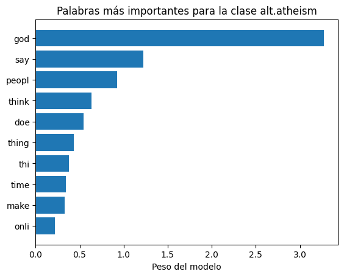

```python
import matplotlib.pyplot as plt

clase_idx = 0  # alt.atheism

top_indices = np.argsort(coeficientes[clase_idx])[-10:]

palabras = feature_names[top_indices]
pesos = coeficientes[clase_idx][top_indices]

plt.barh(palabras, pesos)
plt.title("Palabras más importantes para la clase alt.atheism")
plt.xlabel("Peso del modelo")
plt.show()
```

### Conclusiones

- Se realizó el preprocesamiento del texto para limpiar y normalizar los documentos, reduciendo ruido en el dataset.
- Los textos se transformaron en representaciones numéricas mediante **Bag of Words (BoW)** y **TF-IDF**.
- La representación **TF-IDF** permitió identificar las palabras más relevantes dentro del corpus.
- Se entrenó un modelo de **Regresión Logística** utilizando estas representaciones para realizar la clasificación.
- A partir de los **coeficientes del modelo**, se identificaron los tokens más influyentes en cada clase.